# Identification of reindeer fine-scale foraging behaviour using tri-axial accelerometer data

Heidi Rautiainen, with acknowledgements to Måns Karlsson for hidden Markov model

2020-08-26

https://doi.org/10.5061/dryad.8sf7m0cs7

###### Manuscript

https://doi.org/10.1186/s40462-022-00339-0

Description of data handling and of accelerometer data and behavioural data from video recordings.

## Description of files provided

All in .csv format (“,”-separated columns)

- Filename: “acceleration.csv” (for step 1)
- Filename: “annotations.csv” (for step 1)
- Filename: “df4_2s_allIDs.csv” (for step 2)

#### Filename: *“acceleration.csv”*

**Description:** Accelerometer data in three dimensions (x,y,z), animal id, and timestamp using axy-4 loggers from technosmart. Used for step 1 “Data handling_oneID”.

**Column names:**

- “TagID”: Accelerometer ID
- “Timestamp”: H:M:S:OS
- “X”
- “Y”
- “Z”

#### Filename: *“annotations.csv”*

**Description:** Behavioural data from video recordings (labelled and exported csv from BORIS software). Used for step 1 “Data handling_oneID”.

**N/A’s:** default columns from BORIS output, where no notes has been made (e.g. “Description”, Behavorial.category”).

**Column names:**

- “Observation.id”: Chosen observation ID
- “Observation.date”: Date of observations
- “Description”: N/A
- “Subject”: Animal ID (named by accelerometer ID)
- “Behavior”: Observered behaviour
- “Behavioral.category”: Behavioural category
- “Modifiers”: Observered behaviour
- “Behavior.type”: STATE
- “Start..s.”: Starttime of observered behaviour in seconds
- “Stop..s.”: Stoptime of observered behaviour in seconds
- “Duration..s.”: Duration of observered behaviour in seconds

#### Filename: *“df4_2s_allIDs.csv”*

**Description:** Example dataset of processed data and variables ued (following steps in “Data handling_oneID”) from 19 individuals. Used for step 2 “Training-and-validation-HMM”.

**Description for column names** given for acceleration (X, Y and Z), static acceleration (stX, stY, stZ) and dynamic acceleration (dyX, dyY, dyZ):

- “samp”: Window number (segment)
- “mrot_”: Median (of rotated values) for each axis in each window
- “drot_”: Third quantile (Q3) subtracted by the first quantile (Q1) for each axis
- “meanrot_”: Mean value for each axis in each window
- “minrot_”: Minimum value for each axis in each window
- “maxrot_”: Maximum value for each axis in each window
- “sdrot_”: Standard deviation for each axis in each window
- “mroll”/“mpitch”: Median for roll and pitch in each window
- “droll”/“dpitch”: Third quantile (Q3) subtracted by the first quantile (Q1) for roll and pitch in each window
- “ID”: Animal ID = Accelerometer ID
- “Timestamp”: Y-M-D H:M.S
- “Modifiers”: Behaviour

## Description of data handling

### Step 1: Data handling_oneID

**Files**: “annotations.csv” and “acceleration.csv”

Example data given for one individual for data processing.

##### a. Examples of initial data handling

- Basic data handling

##### b. Merging of acceleration and behaviour

- Fix date and time format
- Add behaviours (or modifiers) to acceleration file
- Data merging ends (acceleration for each start-stop of behaviour)

##### c. Filtering, computation of variables and rotation matrices

- Filtering using running mean
- Raw acceleration in bits (X, Y, Z)
- Static acceleration (stX, stY, stZ)
- Dynamic acceleration (dX, dY, dZ)
- Pitch (rotation around Y axis)
- Roll (rotation around X axis)
- Rotation matrix around X to account for rotation around the neck
- VeDBA (orientation independent variable)
- PDBA (partial dynamic acceleration)

##### d. Segmentation of data to two second windows with the most common behavior

- 2, 3 or 5 second windows with most common behavior
- Example only for using 2 sec window

### Step 2: Training-and-validation-HMM

**File**: “df4_2s_allIDs.csv”

Example code given for the final model (hidden Markov model) for 19 individuals. Random forests, Support vector machines or forward feature selection not included here (see packages used in manuscript). Example data is given for a subset of 200 observations for each individual for demonstration to enable fast processing.

## Code and software

Behaviours labelled from video recordings using BORIS Version 7.9.8. Data handling, model training and validation performed in R (R version 4.0.3 and RStudio version 1.3.1093). Note: Although not part of this manuscript, predictions on new individuals done using Anaconda https://www.anaconda.com/products/distribution to enable fast processing of data.

## Step 1: Data handling_oneID

### Packages

```r
# rm(list=ls())
library(dplyr)
library(base)
library(tidyverse)
```

### 1a Examples of initial prepration

Make sure synchronization of acceleration and behaviour is done

```r
annotations <- read.csv("annotations.csv", dec =",") # exported csv of behaviours labelled using BORIS software
acceleration <- read.csv("acceleration.csv", dec =",") # acceleration in three-dimensions using axy-4 loggers from technsmart


#Change column names
annotations <- annotations %>%
  rename(
  Observation_ID = Observation.id,
  Behavioral_category = Behavioral.category,
  Behavior_type = Behavior.type,
  Start_s = Start..s.,
  Stop_s = Stop..s.,
  Duration_s = Duration..s.,
  Observation_date = Observation.date)

annotations$Observation_date <- as.Date(annotations$Observation_date, format = "%Y-%m-%d")

# Convert seconds to posixct datetime
annotations$Start <- as.numeric(annotations$Start_s)
annotations$Stop <- as.numeric(annotations$Stop_s)

annotations$Start <- as.POSIXct(annotations$Start,
                                origin = "2020-02-27",
                                tz = "UTC")
annotations$Stop <- as.POSIXct(annotations$Stop,
                               origin = "2020-02-27",
                               tz = "UTC")

dt1 <- acceleration
dt2 <- annotations
# write.csv(acceleration, "dt1.csv", row.names = F)
# write.csv(annotations, "dt2.csv", row.names = F)
```

### 1b Merge acceleration and labels (behaviour)

```r
# dt1 <-read.csv("dt1.csv",header=T) # acceleration
# dt2 <-read.csv("dt2.csv",header=T) # behaviour

dt1$Timestamp <- as.POSIXct(dt1$Timestamp)
dt2$Start <- as.POSIXct(dt2$Start)
dt2$Stop <- as.POSIXct(dt2$Stop)


# Create df2 -------------------------------------------------------------------
# Merge acceleration with annotations
# MERGING behavior: Add column for behavior i acceleration file - pick the behavior/modifier!
# Add modifier (instead of using "behavior")

# replace na's in modifiers with behavior
dt2$Modifiers[is.na(dt2$Modifiers)] <- dt2$Behavior[is.na(dt2$Modifiers)]

# Merge rumination and resting
dt2$Modifiers <- dt2$Modifiers %>% str_replace("Ruminating", "Resting")
dt2$Modifiers <- dt2$Modifiers %>% str_replace("Hole", "Ground")


# Add behaviors (or modifiers) to acceleration file
dt1$Modifiers<-NA
    for(i in 1:nrow(dt2)){
    dt1$Modifiers[(dt1$Timestamp>=dt2$Start[i] &
                 dt1$Timestamp<=dt2$Stop[i])]<-dt2$Modifiers[i]}

# Data merging ends
df2 <- na.omit(dt1) # new df without NA rows (no annotations made)
BC <- table(df2$Modifiers) # num of acceleration rows for each behavior (sum(BC)) [1] 167460
BC<-names(BC) # All behaviours
r1<-rle(df2$Modifiers) # lengths (acc) and values (behavior) of runs of equal values in a vector i.e., all observations "start" to "stop"
cr<-cumsum(r1$lengths) # Returns a vector whose elements are the cumulative sums of the elements of the argument (rum for each row)

head(df2, n=50)
```

```
##      TagID           Timestamp     X      Y     Z Modifiers
## 5762  Acc2 2020-02-27 11:35:45 0.063 -0.625 0.625     Other
## 5763  Acc2 2020-02-27 11:35:45 0.063 -0.688 0.563     Other
## 5764  Acc2 2020-02-27 11:35:45 0.125 -0.625 0.688     Other
## 5765  Acc2 2020-02-27 11:35:45 0.125 -0.563 0.625     Other
## 5766  Acc2 2020-02-27 11:35:45 0.125 -0.625 0.688     Other
## 5767  Acc2 2020-02-27 11:35:45 0.250 -0.563 0.625     Other
## 5768  Acc2 2020-02-27 11:35:45 0.250 -0.750 0.625     Other
## 5769  Acc2 2020-02-27 11:35:45 0.250 -0.688 0.500     Other
## 5770  Acc2 2020-02-27 11:35:45 0.125 -0.750 0.625     Other
## 5771  Acc2 2020-02-27 11:35:45 0.250 -0.625 0.563     Other
## 5772  Acc2 2020-02-27 11:35:46 0.313 -0.750 0.813     Other
## 5773  Acc2 2020-02-27 11:35:46 0.313 -0.625 0.813     Other
## 5774  Acc2 2020-02-27 11:35:46 0.375 -0.563 0.625     Other
## 5775  Acc2 2020-02-27 11:35:46 0.313 -0.563 0.688     Other
```

[output cut: 36 more lines]

```r
# write.csv(df2, "df2.csv", row.names = F)
```

### 1c Filtering, variables and rotation matrices

Required to extract static acceleration (remove dynamic acceleration from raw acceleteration in bits) in order to calculate pitch and roll (roll is needed for accounting for the rotation of the collar around the neck)

```r
# rm(list=ls())

# Set sampling frequency and timestep of the running mean
Hz=10 # sampling frequency
Duration=5 # window size (seconds) for calculating running mean
AccHz=Hz*Duration/2 # see e.g., McClune DW et al. 2014 Fehlmann et al 2017

library(chron)
Mov.Av.<-function(obj){
  ma <- obj
  for(i in AccHz:length(obj)) {
    ma[i] <- mean(obj[(i-AccHz):(i+AccHz)], na.rm=TRUE)
  }

  # First points set to NA
  for(i in 1:AccHz) {
    ma[i] <- NA
  }

  # Last points set to NA as well
  for(i in (length(obj)-AccHz):length(obj)) {
    ma[i] <- NA
  }

  return(ma)
}
```

##### Set up parameters

```r
# df3 <- read.csv("df2.csv", dec =",")
df3 <- df2
df3$Timestamp <- as.POSIXct(df3$Timestamp, tz="UTC")
df3$X <- as.numeric(df3$X)
df3$Y <- as.numeric(df3$Y)
df3$Z <- as.numeric(df3$Z)

str(df3)
```

```
## 'data.frame':    28518 obs. of  6 variables:
##  $ TagID    : chr  "Acc2" "Acc2" "Acc2" "Acc2" ...
##  $ Timestamp: POSIXct, format: "2020-02-27 11:35:45" "2020-02-27 11:35:45" ...
##  $ X        : num  0.063 0.063 0.125 0.125 0.125 0.25 0.25 0.25 0.125 0.25 ...
##  $ Y        : num  -0.625 -0.688 -0.625 -0.563 -0.625 -0.563 -0.75 -0.688 -0.75 -0.625 ...
##  $ Z        : num  0.625 0.563 0.688 0.625 0.688 0.625 0.625 0.5 0.625 0.563 ...
##  $ Modifiers: chr  "Other" "Other" "Other" "Other" ...
##  - attr(*, "na.action")= 'omit' Named int [1:41483] 1 2 3 4 5 6 7 8 9 10 ...
##   ..- attr(*, "names")= chr [1:41483] "1" "2" "3" "4" ...
```

```r
# STATIC ACCELERATION
df3$stX=Mov.Av.(df3$X)
df3$stY=Mov.Av.(df3$Y)
df3$stZ=Mov.Av.(df3$Z)

# Dynamic acceleration (DBA) (Dy) ----
df3$dyX=df3$X-df3$stX
df3$dyY=df3$Y-df3$stY
df3$dyZ=df3$Z-df3$stZ


# Roll
roll <- function (y, z)
  {roll = atan2(y, z)
  return(roll)}

df3$roll <- roll(df3$stY, df3$stZ)


# Pitch
pitch2 <- function (x, y, z)
  {pitch90 = 1/atan(-x/sqrt(y^2 + z^2))
  return(pitch90)}
df3$pitch <- pitch2(df3$stX, df3$stY, df3$stZ)#*180/pi


#Rotation matrix
xaxis_rotation <- function(alpha) {
  #' @description This function takes an angel in radians and returns the
  #' matrix that you multiply a vector with to rotate the vector alpha radians
  #' around the x-axis.
  #'
  #' @param alpha the angle in radian.
  #' @return the rotation matrix R

  R <- matrix(nrow = 3, ncol = 3,
              data = c(1, 0, 0,
                       0, cos(alpha), -sin(alpha),
                       0, sin(alpha), cos(alpha)))
  return(R)
}

# Compute all the rotation matrices based on all roll values, save in list
rotation_matrices <- lapply(df3$roll, xaxis_rotation)

# Compute all corrected acceleration values
rotated <- t(sapply(1:length(rotation_matrices), function(i) {
  return(solve(rotation_matrices[[i]]) %*% c(df3$X[i], df3$Y[i], df3$Z[i]))
}))


df3$rotX <- rotated[,1]
df3$rotY <- rotated[,2]
df3$rotZ <- rotated[,3]


### for dynamic acceleration
rotated_dynamic <- t(sapply(1:length(rotation_matrices), function(i) {
  return(solve(rotation_matrices[[i]]) %*% c(df3$dyX[i], df3$dyY[i], df3$dyZ[i]))
}))


df3$rot_dyX <- rotated_dynamic[,1]
df3$rot_dyY <- rotated_dynamic[,2]
df3$rot_dyZ <- rotated_dynamic[,3]


# For static acceleration
rotated_static <- t(sapply(1:length(rotation_matrices), function(i) {
  return(solve(rotation_matrices[[i]]) %*% c(df3$stX[i], df3$stY[i], df3$stZ[i]))
}))



df3$rot_stX <- rotated_static[,1]
df3$rot_stY <- rotated_static[,2]
df3$rot_stZ <- rotated_static[,3]

# # Orientation independent features (veDBA)
# df3$VeDBA=sqrt(df3$dyX^2+df3$dyY^2+df3$dyZ^2)
#
#
# ## #D Magnitude vector
# df3$Norm=sqrt(df3$X^2+df3$Y^2+df3$Z^2)
#

# ---- PDBA ----
# df3$PDBAX=base::abs(df3$dyX)
# df3$PDBAY=base::abs(df3$dyY)
# df3$PDBAZ=base::abs(df3$dyZ)
# ---- Decription: PDBA ----
# Partial Dynamic Body Acceleration


# ---- Ratio VeDBA-Dy (Dynamic acceleration) ----
# df3$RatioX=df3$VeDBA/df3$PDBAX
# df3$RatioY=df3$VeDBA/df3$PDBAY
# df3$RatioZ=df3$VeDBA/df3$PDBAZ

df3 <- na.omit(df3)
head(df3, n=20)
```

```
##      TagID           Timestamp     X      Y     Z Modifiers       stX
## 5787  Acc2 2020-02-27 11:35:47 0.313 -0.625 0.750     Other 0.2698431
## 5788  Acc2 2020-02-27 11:35:47 0.313 -0.625 0.625     Other 0.2759608
## 5789  Acc2 2020-02-27 11:35:47 0.188 -0.625 0.625     Other 0.2833137
## 5790  Acc2 2020-02-27 11:35:47 0.375 -0.500 0.500     Other 0.2882157
## 5791  Acc2 2020-02-27 11:35:47 0.375 -0.625 0.625     Other 0.2943529
## 5792  Acc2 2020-02-27 11:35:48 0.250 -0.750 0.688     Other 0.3017059
## 5793  Acc2 2020-02-27 11:35:48 0.188 -0.688 0.688     Other 0.3066078
## 5794  Acc2 2020-02-27 11:35:48 0.250 -0.750 0.688     Other 0.3115098
## 5795  Acc2 2020-02-27 11:35:48 0.250 -0.563 0.563     Other 0.3151961
## 5796  Acc2 2020-02-27 11:35:48 0.250 -0.688 0.625     Other 0.3213333
## 5797  Acc2 2020-02-27 11:35:48 0.313 -0.813 0.563     Other 0.3188824
## 5798  Acc2 2020-02-27 11:35:48 0.250 -0.938 0.750     Other 0.3188824
## 5799  Acc2 2020-02-27 11:35:48 0.250 -0.875 0.625     Other 0.3176471
## 5800  Acc2 2020-02-27 11:35:48 0.313 -0.813 0.625     Other 0.3127451
```

[output cut: 69 more lines]

```r
# write.csv(df3, "df3.csv", row.names = F)
```

### 1d Two second windows with the most common behavior

To create 2, 3 and 5 sec windows. Here with an example for creating 2 second windows.

```r
# rm(list=ls())

# df3 <- read.csv("df3.csv")
df3$Timestamp <- as.POSIXct(df3$Timestamp, tz="UTC")
# Sampling and feature selection starts
mnt<-min(df3$Timestamp)
mxt<-max(df3$Timestamp)

# Check how many 5 second chunks can we extract
pop<-seq(from=mnt,to=(mxt-2), by=2) #note: here by 2; no overlapping segements

### Take every or every Xth (here every) chunk, starting at a random chunk


# Strategy for randomly selecting the windows
strt<-sample(1:2,size=1)
samp<-pop[seq(strt,length(pop),by=1)]
N <-length(samp)
df4_2s <-data.frame(samp=0,
                    mrot_X=0,drot_X=0,mrot_Y=0,drot_Y=0,mrot_Z=0,drot_Z=0,
                    mrot_stX=0,drot_stX=0,mrot_stY=0,drot_stY=0,mrot_stZ=0,drot_stZ=0,
                    mrot_dyX=0,drot_dyX=0,mrot_dyY=0,drot_dyY=0,mrot_dyZ=0,drot_dyZ=0,
                    meanrot_stx=0, meanrot_sty=0, meanrot_stz=0, meanrot_dyx=0, meanrot_dyy=0, meanrot_dyz=0,
                    minrot_stx=0, minrot_sty=0, minrot_stz=0, maxrot_stx=0, maxrot_sty=0, maxrot_stz=0,
                    minrot_dyx=0, minrot_dyy=0, minrot_dyz=0, maxrot_dyx=0, maxrot_dyy=0, maxdrot_yz=0,
                    sdrot_stx=0, sdrot_sty=0, sdrot_stz=0, sdrot_dyx=0, sdrot_dyy=0, sdrot_dyz=0,
         mroll=0, droll=0, mpitch=0, dpitch=0, #mVeDBA=0, dVeDBA=0, meanVeDBA=0, minVeDBA=0, maxVeDBA=0,sdVeDBA=0,
         ID=0, Timestamp=0, Modifiers=NA)
k<-0

# Run the loop
for(i in 1:N){
  cdt <- df3[(df3$Timestamp>=samp[i] & df3$Timestamp<(samp[i]+2)),]
  if (nrow(cdt) > 19){
    qrot_x <- quantile(cdt$rotX, c(.25, .5, .75))
    qrot_y <- quantile(cdt$rotY, c(.25, .5, .75))
    qrot_z <- quantile(cdt$rotZ, c(.25, .5, .75))
    qrot_stx <- quantile(cdt$rot_stX, c(.25, .5, .75))
    qrot_sty <- quantile(cdt$rot_stY, c(.25, .5, .75))
    qrot_stz <- quantile(cdt$rot_stZ, c(.25, .5, .75))
    qrot_dyx <- quantile(cdt$rot_dyX, c(.25, .5, .75))
    qrot_dyy <- quantile(cdt$rot_dyY, c(.25, .5, .75))
    qrot_dyz <- quantile(cdt$rot_dyZ, c(.25, .5, .75))
    meanrot_stx <- mean(cdt$rot_stX)
    meanrot_sty <- mean(cdt$rot_stY)
    meanrot_stz <- mean(cdt$rot_stZ)
    meanrot_dyx <- mean(cdt$rot_dyX)
    meanrot_dyy <- mean(cdt$rot_dyY)
    meanrot_dyz <- mean(cdt$rot_dyZ)
    minrot_stx <- min(cdt$rot_stX)
    minrot_sty <- min(cdt$rot_stY)
    minrot_stz <- min(cdt$rot_stZ)
    maxrot_stx <- max(cdt$rot_stX)
    maxrot_sty <- max(cdt$rot_stY)
    maxrot_stz <- max(cdt$rot_stZ)
    minrot_dyx <- min(cdt$rot_dyX)
    minrot_dyy <- min(cdt$rot_dyY)
    minrot_dyz <- min(cdt$rot_dyZ)
    maxrot_dyx <- max(cdt$rot_dyX)
    maxrot_dyy <- max(cdt$rot_dyY)
    maxrot_dyz <- max(cdt$rot_dyZ)
    sdrot_stx <- sd(cdt$rot_stX)
    sdrot_sty <- sd(cdt$rot_stY)
    sdrot_stz <- sd(cdt$rot_stZ)
    sdrot_dyx <- sd(cdt$rot_dyX)
    sdrot_dyy <- sd(cdt$rot_dyY)
    sdrot_dyz <- sd(cdt$rot_dyZ)

    qroll <- quantile(cdt$roll, c(.25, .5, .75))
    qpitch <- quantile(cdt$pitch, c(.25, .5, .75))
    # qVeDBA <- quantile(cdt$VeDBA, c(.25, .5, .75))
    # meanVeDBA  <- mean(cdt$VeDBA)
    # minVeDBA  <- min(cdt$VeDBA)
    # maxVeDBA  <- max(cdt$VeDBA)
    # sdVeDBA <- sd(cdt$VeDBA)
    B <- table(cdt$Modifiers) # what the animal was doing
    Bm <- names(B)[which(B==max(B))] # choose the most common behavior (grazing in this case)
    Bm <-Bm[1]
    C <- format(as.POSIXct(cdt$Timestamp))
    Cm <- C[1]
    D <- as.character(cdt$TagID)
    Dm <- D[1]
    k<-k+1
    df4_2s[k,1:47]<-as.numeric(c(i,
   qrot_x[2],(qrot_x[3]-qrot_x[1]),qrot_y[2],(qrot_y[3]-qrot_y[1]),qrot_z[2],(qrot_z[3]-qrot_z[1]),
   qrot_stx[2],(qrot_stx[3]-qrot_stx[1]),qrot_sty[2],(qrot_sty[3]-qrot_sty[1]),qrot_stz[2],(qrot_stz[3]-qrot_stz[1]),
   qrot_dyx[2],(qrot_dyx[3]-qrot_dyx[1]),qrot_dyy[2],(qrot_dyy[3]-qrot_dyy[1]),qrot_dyz[2],(qrot_dyz[3]-qrot_dyz[1]),
   meanrot_stx[1], meanrot_sty[1], meanrot_stz[1], meanrot_dyx[1], meanrot_dyy[1], meanrot_dyz[1],
   minrot_stx[1], minrot_sty[1], minrot_stz[1], maxrot_stx[1], maxrot_sty[1], maxrot_stz[1],
   minrot_dyx[1], minrot_dyy[1], minrot_dyz[1], maxrot_dyx[1], maxrot_dyy[1], maxrot_dyz[1],
   sdrot_stx[1], sdrot_sty[1], sdrot_stz[1], sdrot_dyx[1], sdrot_dyy[1], sdrot_dyz[1],

                              qroll[2],(qroll[3]-qroll[1]),qpitch[2],(qpitch[3]-qpitch[1])
                            #  qVeDBA[2],(qVeDBA[3]-qVeDBA[1]), meanVeDBA[1], minVeDBA[1], maxVeDBA[1], sdVeDBA[1]))
))
    df4_2s$Modifiers[k]<-Bm
    df4_2s$Timestamp[k]<-Cm
    df4_2s$ID[k]<-Dm

  }
}

head(df4_2s)
```

```
##   samp mrot_X  drot_X      mrot_Y     drot_Y    mrot_Z    drot_Z   mrot_stX
## 1    1 0.2500 0.06300  0.05693463 0.17280235 0.9555046 0.1343848 0.30415686
## 2    8 0.0940 0.07775  0.12929967 0.19766475 0.8364351 0.5861066 0.17604902
## 3    9 0.0000 0.07850 -0.04841045 0.28524184 0.9057703 0.5264774 0.02518627
## 4   12 0.1880 0.32850 -0.02115151 0.29641835 1.0317030 0.2393913 0.13404902
## 5   13 0.1220 0.16925  0.03719159 0.09692061 0.9953209 0.1010919 0.10213725
## 6   16 0.2815 0.20350 -0.09062323 0.25638871 1.0961520 0.7776447 0.20611765
##     drot_stX      mrot_stY     drot_stY  mrot_stZ   drot_stZ     mrot_dyX
## 1 0.02145098 -5.551115e-17 6.938894e-17 0.9330028 0.01861524 -0.047421569
## 2 0.04815196 -5.551115e-17 1.249001e-16 0.9258196 0.01839830 -0.081431373
## 3 0.05797549 -2.775558e-17 6.938894e-17 0.9328898 0.03917181 -0.004941176
## 4 0.01777451 -1.110223e-16 1.110223e-16 1.0018486 0.01586696  0.070088235
## 5 0.03960784 -2.775558e-17 1.942890e-16 0.9980928 0.02298047  0.035794118
## 6 0.03007353  0.000000e+00 1.665335e-16 1.0788585 0.03248917  0.072333333
##     drot_dyX    mrot_dyY   drot_dyY     mrot_dyZ  drot_dyZ meanrot_stx
```

[output cut: 41 more lines]

```r
# write.csv(df4_2s, "df4.csv", row.names = F)
```

## Step 2: Training-and-validation-HMM

### Packages

```r
# rm(list=ls())
library(dplyr)
library(mvtnorm)
library(ggplot2)
library(MCMCpack)
library(reshape2)
```

## Load data

```r
df4_2s_all <- read.csv("df4_2s_allIDs.csv")

unique(df4_2s_all$ID)
```

```
##  [1]  1  2  3  5  6  7  8  9 10 11 12 13 14 15 16 17 18 19 20
```

```r
d <- df4_2s_all


### Pre-settings and check data ----


# Merging behaviours
# d <- read.csv("df4_relief_5s", sep=",", header=TRUE)
# d<-d[!(d$Modifiers=="Missing data"),]
# d<-d[!(d$Modifiers=="Accelerometer"),]
# d<-d[!(d$Modifiers=="Digging"),]
#
# d$Modifiers <- d$Modifiers %>% stringr::str_replace("Breaking branches", "Other")
# d$Modifiers <- d$Modifiers %>% stringr::str_replace("Agnostic behavior", "Other")
# d$Modifiers <- d$Modifiers %>% stringr::str_replace("Grooming", "Other")
# d$Modifiers <- d$Modifiers %>% stringr::str_replace("Hind legs", "High")
# d$Modifiers <- d$Modifiers %>% stringr::str_replace("While walking", "Ground")
# d$Modifiers <- d$Modifiers %>% stringr::str_replace("Hole", "Ground")
# d$Modifiers <- d$Modifiers %>% stringr::str_replace("Running", "Trotting")
# d$Modifiers <- d$Modifiers %>% stringr::str_replace("Ruminating", "Resting")
# d$Modifiers <- d$Modifiers %>% stringr::str_replace("Standing", "Resting")
# d$Modifiers <- d$Modifiers %>% stringr::str_replace("Sleeping", "Resting")
# d$Modifiers<- as.factor(d$Modifiers)

# d <- d %>% group_by(ID) %>% sample_n(size = 200)
# write.csv(d, "df4_2s_allIDs.csv", row.names = F)


dtouse <- d[, c("meanrot_stx", "sdrot_dyz", "drot_Y", "droll", "maxrot_dyx", "minrot_sty", "sdrot_stx", "mrot_Y")] #mean_sX, sd_dZ, IQR_Y, IQR_roll, max_dX, min_sY, sd_sX and m_Y
dtouse$Modifiers <- d$Modifiers
dtouse$ID <- d$ID
smalld <- dtouse
unique(smalld$Modifiers)
```

```
## [1] "Low"      "Walking"  "Resting"  "Ground"   "Other"    "High"     "Trotting"
```

## tpm_general

Where each reindeer has equal weight

```r
# Number of (hidden) states (behaviours)
behaviours <- sort(unique(d$Modifiers)); behaviours
```

```
## [1] "Ground"   "High"     "Low"      "Other"    "Resting"  "Trotting" "Walking"
```

```r
m <- length(behaviours); m
```

```
## [1] 7
```

```r
# Prior (from one behaviour to another)
prior_matrix <- matrix(1/m,m,m)
dimnames(prior_matrix) <- list(behaviours,behaviours); dimnames(prior_matrix)
```

```
## [[1]]
## [1] "Ground"   "High"     "Low"      "Other"    "Resting"  "Trotting" "Walking"
##
## [[2]]
## [1] "Ground"   "High"     "Low"      "Other"    "Resting"  "Trotting" "Walking"
```

```r
# Estimating initial distribution
init_dist <- table(d$Modifiers)/nrow(d); init_dist
```

```
##
##      Ground        High         Low       Other     Resting    Trotting
## 0.281315789 0.006842105 0.238421053 0.023421053 0.334473684 0.019473684
##     Walking
## 0.096052632
```

```r
# Mean (mu) observations of predictor variables for each state
d %>% group_by(Modifiers) %>% summarize(mrot_Ym  = mean(mrot_Y),
                                        drot_Ym = mean(drot_Y),
                                        meanrot_stxm = mean(meanrot_stx),
                                        meanrot_dyxm = mean(meanrot_dyx),
                                        maxrot_dyxm = mean(maxrot_dyx),
                                        sdrot_stxm = mean(sdrot_stx),
                                        sdrot_dyzm = mean(sdrot_dyz),
                                        drollm = mean(droll)) -> mean_estimates; mean_estimates
```

```
## # A tibble: 7 × 9
##   Modifiers   mrot_Ym drot_Ym meanrot_stxm meanrot_dyxm maxrot_dyxm sdrot_stxm
##   <chr>         <dbl>   <dbl>        <dbl>        <dbl>       <dbl>      <dbl>
## 1 Ground     0.000245  0.0612     -0.438       -0.0226       0.0878     0.0215
## 2 High       0.0152    0.0839      0.512        0.0429       0.155      0.0280
## 3 Low       -0.00206   0.0814      0.105        0.00854      0.115      0.0217
## 4 Other     -0.00846   0.179      -0.00442     -0.0207       0.299      0.0306
## 5 Resting   -0.000881  0.0240      0.267        0.0214       0.0664     0.0151
## 6 Trotting   0.0188    0.222       0.178        0.0266       0.388      0.0254
## 7 Walking   -0.00127   0.0725      0.0156       0.0136       0.194      0.0303
## # ℹ 2 more variables: sdrot_dyzm <dbl>, drollm <dbl>
```

```r
# estimating covmats (variance-covariance) for each behaviour
d %>% group_by(Modifiers) %>%  dplyr::select(mrot_Y, drot_Y, meanrot_stx, meanrot_dyx, maxrot_dyx, sdrot_stx, sdrot_dyz, droll) -> d_temp; d_temp
```

```
## # A tibble: 3,800 × 9
## # Groups:   Modifiers [7]
##    Modifiers    mrot_Y  drot_Y meanrot_stx meanrot_dyx maxrot_dyx sdrot_stx
##    <chr>         <dbl>   <dbl>       <dbl>       <dbl>      <dbl>     <dbl>
##  1 Low       -1.29e- 2 0.0310       0.0235    0.0262      0.0410    0.00271
##  2 Walking   -3.01e- 2 0.0641       0.0816    0.153       0.297     0.0359
##  3 Resting    5.80e- 4 0.00130      0.444     0.00942     0.0559    0
##  4 Resting    1.01e- 2 0.0327       0.374    -0.00188     0.00122   0
##  5 Resting   -5.55e-17 0.00224      0.507    -0.00402     0.0352    0.00158
##  6 Low        6.89e- 3 0.0549      -0.0103   -0.0117      0.0136    0.00180
##  7 Resting   -5.55e-17 0.00114      0.559     0.000556    0.00371   0
##  8 Resting   -4.55e- 3 0.0503       0.351    -0.00769     0.0259    0.00206
##  9 Resting    9.13e- 3 0.0167       0.437     0.00148     0.00371   0.00177
## 10 Low        1.37e- 2 0.0944       0.0227    0.00243     0.0996    0.00362
## # ℹ 3,790 more rows
## # ℹ 2 more variables: sdrot_dyz <dbl>, droll <dbl>
```

```r
cov_estimates <- by(d_temp[-1], d_temp$Modifiers, cov , use="na.or.complete")
# NOTES: variance-covariance matrices for the observations in each state.

# If you want correlation matrices from covariance matrices, use
# cov2cor(cov_estimates[[1]]) #


# Split data for each reindeer
d %>% group_split(ID) -> d_split

# Extract the states
d_mods <- sapply(d_split, function(df) {
  return(df$Modifiers)
})
length(d_mods);
```

```
## [1] 3800
```

```r
# Counts ----------------------------------------------------------------
# Function to estimate first-order Markov transition matrix.
# Each *row* corresponds to a single run of the Markov chain
trans.matrix <- function(X, prob=T) {
  trans_counts <- table(c(X[,-ncol(X)]), c(X[,-1]))
  if(prob) trans_counts <- trans_counts / rowSums(trans_counts) # normalizing so each row sums to 1
  trans_counts
}

tapply(d$Modifiers, d$ID, unique) # no of behaviours for each individual
```

```
## $`1`
## [1] "Low"     "Walking" "Resting" "Ground"  "Other"   "High"
##
## $`2`
## [1] "Resting" "Low"     "Ground"  "Walking" "Other"   "High"
##
## $`3`
## [1] "Walking" "Resting" "Other"   "Ground"  "Low"
##
## $`5`
## [1] "Resting" "Low"     "Ground"  "Walking" "Other"
##
## $`6`
## [1] "Ground"  "Low"     "Walking" "Resting" "High"
##
## $`7`
## [1] "Ground"   "Low"      "Resting"  "Walking"  "High"     "Trotting"
##
## $`8`
## [1] "Resting"  "Ground"   "Low"      "High"     "Trotting" "Walking"  "Other"
##
## $`9`
## [1] "Low"     "Resting" "Ground"  "Walking"
##
## $`10`
## [1] "Low"     "Resting" "Ground"  "Other"   "Walking"
##
## $`11`
## [1] "Ground"   "Walking"  "Resting"  "Trotting"
##
## $`12`
## [1] "Walking"  "Resting"  "Low"      "Trotting" "Ground"   "Other"
##
## $`13`
## [1] "Ground"  "Low"     "Resting" "Walking" "High"
##
## $`14`
## [1] "Resting"  "Trotting" "Ground"   "Walking"  "Low"
##
## $`15`
## [1] "Low"      "Ground"   "Walking"  "High"     "Other"    "Resting"  "Trotting"
##
## $`16`
## [1] "Walking"  "Ground"   "Resting"  "Low"      "Trotting"
##
## $`17`
## [1] "Low"      "Resting"  "Ground"   "Other"    "Walking"  "Trotting"
##
## $`18`
## [1] "Ground"  "Other"   "Resting" "Low"     "Walking"
##
## $`19`
## [1] "Walking"  "Ground"   "Low"      "Resting"  "Trotting"
##
## $`20`
## [1] "Ground"   "Low"      "Resting"  "Walking"  "Trotting"
```

```r
# Estimates for each individual (1 to 19 in total)
est <- list()
for (k in 1:19){ # 19 for no of individuals
  counts <- trans.matrix(X = matrix(d_mods[[k]], nrow=1), prob=FALSE) # how many times reindeer k goes from one behaviour to another
  b_from <- dimnames(counts)[[1]] # current state
  b_to <- dimnames(counts)[[2]] # next state
  tpm <- prior_matrix #  creates tpm variable
  tpm[b_from,b_to] <- counts + 1/m
  tpm <- tpm/rowSums(tpm) #  statecounts (number of transistions) to probabilities of one behaviour to another (tpm)
  est[[k]] <- tpm #estimates for each reindeer probabilbity matrix
}
length(est)
```

```
## [1] 19
```

```r
# Compute the general tpm without using reindeer 1
# We weight it so that each reindeer has equal weight
tpm_general <- Reduce(f = "+", x = est)/19; tpm_general
```

```
##             Ground      High       Low     Other   Resting  Trotting   Walking
## Ground   0.1428571 0.1428571 0.1428571 0.1428571 0.1428571 0.1428571 0.1428571
## High     0.1428571 0.1428571 0.1428571 0.1428571 0.1428571 0.1428571 0.1428571
## Low      0.1428571 0.1428571 0.1428571 0.1428571 0.1428571 0.1428571 0.1428571
## Other    0.1428571 0.1428571 0.1428571 0.1428571 0.1428571 0.1428571 0.1428571
## Resting  0.1428571 0.1428571 0.1428571 0.1428571 0.1428571 0.1428571 0.1428571
## Trotting 0.1428571 0.1428571 0.1428571 0.1428571 0.1428571 0.1428571 0.1428571
## Walking  0.1428571 0.1428571 0.1428571 0.1428571 0.1428571 0.1428571 0.1428571
```

## Load functions

```r
HMM.viterbi <- function(x, m, gamma, allprobs, delta=NULL, ...) { # Viterbi adjusted from Leos-Barajas et al. 2017
  if(is.null(delta)) {
    delta <- solve(t(diag(m) - gamma + 1), rep(1, m))
  }
  #cat("allprobs",summary(c(allprobs)),"\n")
  #print(allprobs)
  n <- dim(x)[1]
  xi <- matrix(0, n, m)
  foo <- delta * allprobs[1,]
  xi[1,] <- foo/sum(foo)
  #cat("foo",foo,"\n")
  for(i in 2:n) {
    foo <- apply(xi[i-1,]*gamma, 2, max)*allprobs[i,]
    #cat("foo",foo,"\n")
    xi[i,] <- foo/sum(foo)
  }
  #cat("foo",foo,"\n")

  iv <- numeric(n)
  #cat("xi[n,]",xi[n,],"\n")
  iv[n] <- rownames(gamma)[which.max(xi[n,])]
  for(i in (n-1):1) {
    iv[i] <- rownames(gamma)[which.max(gamma[, iv[i+1]]*xi[i,])]
  }
  return(iv)
}
tpm.est <- function(df = d, response="Modifiers", groupid = "ID") {
  #' @description this function performs leave-one-group out CV for HMM
  #'
  #' @param df the data to fit the model(s) on
  #' @param groupid the variable determining groups
  #' @param response the hidden state variable
  #' @return the tpm estimate

  # First we split data accourding to grouping factor
  df_list <- split(x = df, f = df[[groupid]], drop=FALSE)

  # Then we compute the transition probability matrices for each reindeer
  tpm_list <- lapply(1:nlevels(df[[groupid]]), function(i) {

    # # Compute the number of transitions from state i to state j
    # # Factor, so should always return matrix of same size
    # # prob = TRUE to return a transistion probability matrix directly.
    # # if prob=FALSE, will return count matrix.
    # tpm <- trans.matrix(X = matrix(df_list[[i]][[response]], nrow=1), prob=TRUE)
    counts <- trans.matrix(X = matrix(d_mods[[k]], nrow=1), prob=FALSE)
    b_from <- dimnames(counts)[[1]]
    b_to <- dimnames(counts)[[2]]
    tpm <- prior_matrix
    tpm[b_from,b_to] <- counts + 1/m
    tpm <- tpm/rowSums(tpm)
    est[[k]] <- tpm
    return(tpm)
  })

  # Average to get general transition probability matrix
  # But we need to watch out so that we don't use zeros!

  tpm_gen <- specialreduce(tpm_list, nr = nrow(tpm_list[[1]]), nc = ncol(tpm_list[[1]]))

  return(tpm_gen)
}
specialreduce <- function(lst, nr, nc) {
  #' @description computes the mean transition probability matrix by omitting the
  #' instances of zeros
  temp <- as.array(lst)
  print(temp)
  out <- matrix(nrow = nr, ncol = nc)

  for(i in 1:nr) {
    for(j in 1:nc) {
      vec <- temp[, i, j]
      out[i, j] <- mean(vec[which(vec != 0)])
    }
  }
  return(out)
}
mean.est <- function(df, response="Modifiers", groupid = "ID") {
  #' @description This estimates the mean of the observable variables for each state
  #'
  #' @param df the data to fit the model(s) on
  #' @param groupid the variable determining groups
  #' @param response the hidden state variable
  #' @return the mean estimates

  # First we split data according to THE BEHAVIOUR
  df_list <- split(x = df, f = df[[response]])

  # Compute the mean value of the observable state variables for each reindeer
  mean_ests <- lapply(df_list, function(df_id) {
    # Split according to reindeer
    df_temp2 <- split(df_id, df_id[[groupid]])

    # Compute the mean for each obxervable for each reindeer
    temp <- lapply(df_temp2, function(z) {
      if (nrow(z) == 0) {
        return(rep(NULL, ncol(z) -2))
      } else {
        return(colMeans(z[, -c(ncol(z), ncol(z)-1)]))
      }
    })
    return(temp)
  })

  # Compute mean across reindeeers
  out <- sapply(mean_ests, function(x) {
    tem <- do.call(what = rbind.data.frame, args =x)
    return(colMeans(tem))
  })

  rownames(out) <- NULL
  return(out)
}
mean.est(df = smalld)
```

```
##             Ground          High           Low         Other       Resting
## [1,] -4.252347e-01  5.117278e-01  8.728495e-02 -7.390190e-02  2.605458e-01
## [2,]  7.324994e-02  8.361483e-02  7.393469e-02  1.333891e-01  2.836258e-02
## [3,]  6.144483e-02  8.665531e-02  7.929538e-02  1.286994e-01  2.911426e-02
## [4,]  1.321347e-02  4.736564e-02  2.048841e-02  2.965633e-02  7.898593e-03
## [5,]  9.121802e-02  2.046090e-01  1.146109e-01  1.975408e-01  1.009226e-01
## [6,] -1.741684e-16 -1.217965e-16 -1.741118e-16 -1.534080e-16 -1.580116e-16
## [7,]  2.278258e-02  4.651354e-02  2.230081e-02  2.874697e-02  2.129920e-02
## [8,]  5.739033e-04  2.025688e-02  2.383333e-04 -8.966159e-03 -2.073874e-03
##           Trotting       Walking
## [1,]  1.892829e-01 -1.136833e-02
## [2,]  3.133136e-01  1.082450e-01
## [3,]  1.780322e-01  7.161462e-02
## [4,]  1.761529e-02  1.035162e-02
## [5,]  3.992782e-01  2.014553e-01
## [6,] -1.823249e-16 -1.801596e-16
## [7,]  2.495934e-02  2.926780e-02
## [8,]  6.703243e-03  1.218716e-04
```

```r
cov.est <- function(df, response="Modifiers", groupid = "ID") {
  #' @description This estimates the mean of the observable variables for each state
  #'
  #' @param df the data to fit the model(s) on
  #' @param groupid the variable determining groups
  #' @param response the hidden state variable
  #' @return the mean estimates


  # First we split data according to THE BEHAVIOUR
  df_list <- split(x = df, f = df[[response]])

  # Compute the mean value of the observable state variables for each reindeer
  cov_ests <- lapply(df_list, function(df_id) {

    # Split according to reindeer
    df_temp2 <- split(df_id, df_id[[groupid]])

    # Compute the covariance matrix for observables for each reindeer
    temp <- lapply(df_temp2, function(z) {
      if (nrow(z) < 5) {
        return(NULL)
      } else {
        return(cov(z[, -c(ncol(z), ncol(z)-1)]))
      }
    })
    return(temp)
  })

  # Compute mean across reindeers
  # use reduce
  out <- lapply(cov_ests, function(lst) {
    is_not_null <- which(sapply(lst, function(x) !is.null(x)))
    return(Reduce(f = "+", x = lst[is_not_null])/length(is_not_null))
  })

  return(out)
}
cov.est(df=smalld)
```

```
## $Ground
##               meanrot_stx     sdrot_dyz        drot_Y         droll
## meanrot_stx  1.802666e-02  6.737466e-04  2.330260e-04 -6.218593e-05
## sdrot_dyz    6.737466e-04  3.007521e-03  7.877558e-04  2.770592e-05
## drot_Y       2.330260e-04  7.877558e-04  1.048839e-03  5.137462e-05
## droll       -6.218593e-05  2.770592e-05  5.137462e-05  1.514487e-04
## maxrot_dyx   1.785372e-03  4.440369e-03  1.520338e-03  1.624670e-04
## minrot_sty  -9.268611e-19 -1.276369e-19 -3.990635e-20  1.772293e-20
## sdrot_stx    1.225563e-03  1.728152e-04  7.117645e-05  2.472667e-05
## mrot_Y       3.811965e-05 -2.679311e-04 -5.782830e-05 -1.925396e-05
##                maxrot_dyx    minrot_sty     sdrot_stx        mrot_Y
## meanrot_stx  1.785372e-03 -9.268611e-19  1.225563e-03  3.811965e-05
## sdrot_dyz    4.440369e-03 -1.276369e-19  1.728152e-04 -2.679311e-04
## drot_Y       1.520338e-03 -3.990635e-20  7.117645e-05 -5.782830e-05
## droll        1.624670e-04  1.772293e-20  2.472667e-05 -1.925396e-05
## maxrot_dyx   1.744441e-02  2.469420e-20 -5.682187e-05 -6.342835e-04
## minrot_sty   2.469420e-20  2.346302e-33  4.806674e-21 -9.297262e-20
## sdrot_stx   -5.682187e-05  4.806674e-21  5.947079e-04  2.377693e-05
## mrot_Y      -6.342835e-04 -9.297262e-20  2.377693e-05  8.001668e-04
##
## $High
##               meanrot_stx    sdrot_dyz        drot_Y         droll
## meanrot_stx  1.531361e-02 9.246867e-04  1.739220e-03  8.589047e-04
## sdrot_dyz    9.246867e-04 9.663083e-04  5.770990e-04  1.578619e-04
## drot_Y       1.739220e-03 5.770990e-04  1.727126e-03  1.735308e-04
## droll        8.589047e-04 1.578619e-04  1.735308e-04  3.080880e-04
## maxrot_dyx  -2.330449e-03 9.562877e-04 -1.799267e-04 -1.474174e-04
## minrot_sty   4.005316e-18 7.279870e-19  1.050048e-18  5.675742e-19
## sdrot_stx    2.639382e-05 1.360598e-04  1.193640e-04  3.257780e-05
## mrot_Y       9.510151e-04 2.668264e-04  1.493905e-03 -1.054513e-04
##                maxrot_dyx    minrot_sty     sdrot_stx        mrot_Y
## meanrot_stx -2.330449e-03  4.005316e-18  2.639382e-05  9.510151e-04
## sdrot_dyz    9.562877e-04  7.279870e-19  1.360598e-04  2.668264e-04
## drot_Y      -1.799267e-04  1.050048e-18  1.193640e-04  1.493905e-03
## droll       -1.474174e-04  5.675742e-19  3.257780e-05 -1.054513e-04
## maxrot_dyx   5.067489e-03 -1.069233e-18  5.414773e-04  3.350962e-04
## minrot_sty  -1.069233e-18  2.393655e-33 -5.329608e-20  3.756333e-19
## sdrot_stx    5.414773e-04 -5.329608e-20  1.314819e-04  1.432346e-04
## mrot_Y       3.350962e-04  3.756333e-19  1.432346e-04  2.484635e-03
##
```

[output cut: 84 more lines]

```
## drot_Y       7.312502e-04  3.498074e-04  1.014474e-03  2.262367e-04
## droll       -8.748725e-05  6.175866e-05  2.262367e-04  2.512898e-04
## maxrot_dyx   3.686316e-03  1.614589e-03  3.845296e-04  9.824297e-05
## minrot_sty   1.011916e-18  3.750923e-19  1.469557e-19  2.514244e-20
## sdrot_stx   -2.425860e-04 -2.034090e-05 -9.914354e-07  6.211805e-05
## mrot_Y      -1.142068e-04  8.053227e-05 -1.197830e-04 -1.450693e-04
##                maxrot_dyx    minrot_sty     sdrot_stx        mrot_Y
## meanrot_stx  3.686316e-03  1.011916e-18 -2.425860e-04 -1.142068e-04
## sdrot_dyz    1.614589e-03  3.750923e-19 -2.034090e-05  8.053227e-05
## drot_Y       3.845296e-04  1.469557e-19 -9.914354e-07 -1.197830e-04
## droll        9.824297e-05  2.514244e-20  6.211805e-05 -1.450693e-04
## maxrot_dyx   1.388578e-02  6.545259e-19  3.746452e-04 -1.325342e-04
## minrot_sty   6.545259e-19  2.440300e-33 -1.696467e-20 -2.654270e-20
## sdrot_stx    3.746452e-04 -1.696467e-20  4.951436e-04 -3.463082e-05
## mrot_Y      -1.325342e-04 -2.654270e-20 -3.463082e-05  6.810326e-04
```

```r
predict.HMM <- function(tpm, d, means, covs, init_dist = rep(1/7,7)) {
  #' @description This function predicts the hidden state in each timepoint for
  #' a single reindeer
  #'
  #' @param tpm a transition probability matrix
  #' @param d the data to use for computing state probabilities
  #' @param means the mean vector of the observable state variables
  #' @param covs the covariance matrix of the observable state variables

  # Create matrix to hold state probs
  log_sp <- sp <- matrix(NA, nrow=nrow(d), ncol=ncol(tpm))

  # Compute the value of the density function in each state in each time point
  # for each time point i
  for (i in 1:nrow(sp)) {
    # for each state j
    for(j in 1:ncol(tpm)) {
      # Compute the value of the density function for the observable state variables
      log_sp[i,j] <- dmvnorm(x = d[i, ],
                             mean = means[, j],
                             sigma = covs[[j]],log = TRUE)
    }
  }
  #cat("log_sp\n")
  #print(log_sp)
  # Normalize the rows so sp has the state probabilities.
  for (i in 1:nrow(sp)) {
    maxi <- max(log_sp[i, ])
    s <- exp(log_sp[i, ]-maxi)
    #sp[i, ] <- sp[i, ] / sum(sp[, ])
    sp[i, ] <- s / sum(s)
  }

  # Compute the most probable state in each time point
  pred_state <- HMM.viterbi(x=d, m=ncol(tpm), gamma = tpm, allprobs = sp, delta = init_dist)

  return(pred_state)
}
cv.hmm <- function(df, groupid, tpm = tpm_general, ...) {
  #' @description  This perfoms leave-one-ID-out cross validation

  # First we split data accourding to grouping factor
  df_list <- split(x = df, f = df[[groupid]])

  preds <- lapply(1:length(unique(df[[groupid]])), function(i) {
    cat(i, "\n")
    df_temp <- do.call(what = rbind.data.frame, args = df_list[-i])
    means <- mean.est(df = df_temp, ...)
    covs <- cov.est(df = df_temp, ...)
    #tpm <- tpm.est(df = df_temp, ...)

    to_pred <- df_list[[i]]
    res <- predict.HMM(tpm = tpm, d = to_pred[, -c(ncol(to_pred), ncol(to_pred)-1)],
                       means = means, covs = covs)
    #out <- table(as.character(df_list[[i]][[groupid]]), res)
    #print(res)

    return(res)
  })
  #If it doesn't work remove this row.
  #out2 <- Reduce(f = "+", x = preds)
  return(preds)

}
```

## Leave on ID out cross validation

```r
smalld$Modifiers <- as.factor(smalld$Modifiers)

res <- cv.hmm(d = smalld, groupid = "ID")
```

```
## 1
## 2
## 3
## 4
## 5
## 6
## 7
## 8
## 9
## 10
## 11
## 12
## 13
## 14
## 15
## 16
## 17
## 18
## 19
```

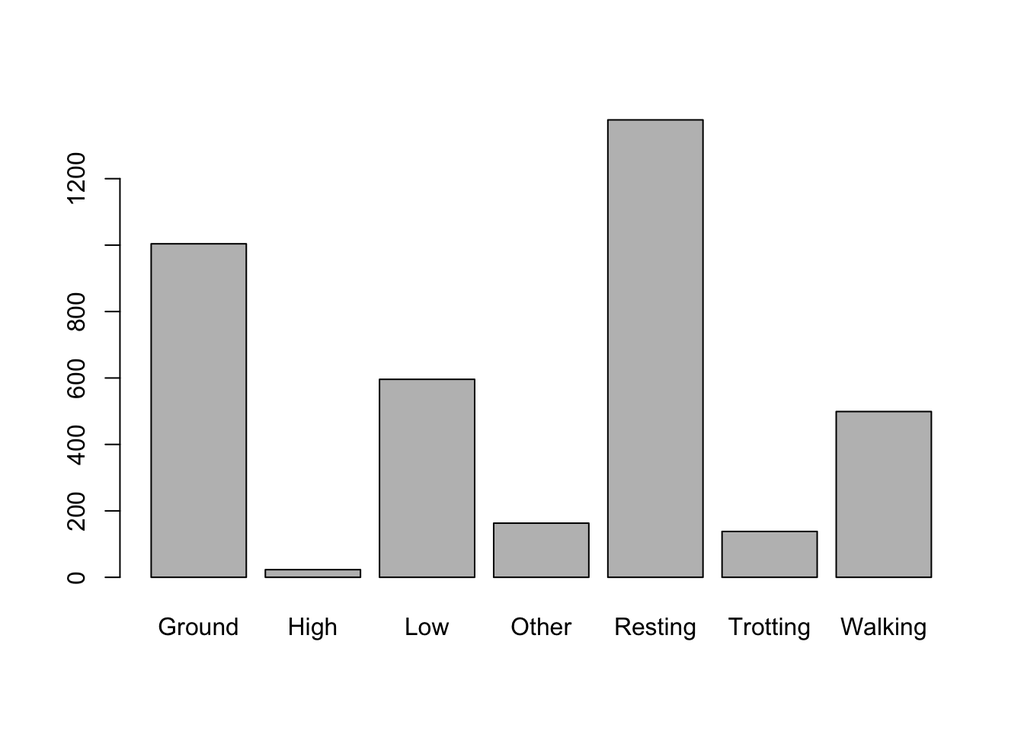

```r
resmat <- matrix(unlist(res))
plot(as.factor(resmat))
```

```r
## confusion matrix
library(caret)
# table(resmat, d$Modifiers, dnn=c("true","pred"))
# cm <- confusionMatrix(as.factor(resmat), as.factor(smalld$Modifiers), mode = "everything", positive="1")
# cm

Predictions_2s <- do.call(what = c, args = res)
confusionMatrix(as.factor(Predictions_2s),as.factor(smalld$Modifiers), mode = "everything")
```

```
## Confusion Matrix and Statistics
##
##           Reference
## Prediction Ground High  Low Other Resting Trotting Walking
##   Ground      928    0   54     2       6        0      14
##   High          0    1   15     1       5        0       1
##   Low          50   18  429     7      44        0      48
##   Other        24    0   72    30      14        5      18
##   Resting       5    5  169     4    1173        0      21
##   Trotting      5    1   14    39       0       64      15
##   Walking      57    1  153     6      29        5     248
##
## Overall Statistics
##
##                Accuracy : 0.7561
##                  95% CI : (0.7421, 0.7696)
##     No Information Rate : 0.3345
##     P-Value [Acc > NIR] : < 2.2e-16
##
##                   Kappa : 0.6759
##
##  Mcnemar's Test P-Value : NA
##
## Statistics by Class:
##
##                      Class: Ground Class: High Class: Low Class: Other
## Sensitivity                 0.8681   0.0384615     0.4735     0.337079
## Specificity                 0.9722   0.9941706     0.9423     0.964161
## Pos Pred Value              0.9243   0.0434783     0.7198     0.184049
## Neg Pred Value              0.9496   0.9933810     0.8511     0.983778
## Precision                   0.9243   0.0434783     0.7198     0.184049
## Recall                      0.8681   0.0384615     0.4735     0.337079
## F1                          0.8953   0.0408163     0.5712     0.238095
## Prevalence                  0.2813   0.0068421     0.2384     0.023421
## Detection Rate              0.2442   0.0002632     0.1129     0.007895
## Detection Prevalence        0.2642   0.0060526     0.1568     0.042895
## Balanced Accuracy           0.9201   0.5163161     0.7079     0.650620
##                      Class: Resting Class: Trotting Class: Walking
## Sensitivity                  0.9229         0.86486        0.67945
## Specificity                  0.9193         0.98014        0.92693
## Pos Pred Value               0.8519         0.46377        0.49699
## Neg Pred Value               0.9596         0.99727        0.96456
## Precision                    0.8519         0.46377        0.49699
## Recall                       0.9229         0.86486        0.67945
## F1                           0.8860         0.60377        0.57407
## Prevalence                   0.3345         0.01947        0.09605
## Detection Rate               0.3087         0.01684        0.06526
## Detection Prevalence         0.3624         0.03632        0.13132
## Balanced Accuracy            0.9211         0.92250        0.80319
```

## training error 2s

```r
d1 <- d %>% filter(ID == "1"); d1 <- d1[, c("meanrot_stx", "sdrot_dyz", "drot_Y", "droll", "maxrot_dyx", "minrot_sty", "sdrot_stx", "mrot_Y")]
d2 <- d %>% filter(ID == "2"); d2<- d2[, c("meanrot_stx", "sdrot_dyz", "drot_Y", "droll", "maxrot_dyx", "minrot_sty", "sdrot_stx", "mrot_Y")]
d3 <- d %>% filter(ID == "3"); d3<- d3[, c("meanrot_stx", "sdrot_dyz", "drot_Y", "droll", "maxrot_dyx", "minrot_sty", "sdrot_stx", "mrot_Y")]
d5 <- d %>% filter(ID == "5"); d5<- d5[, c("meanrot_stx", "sdrot_dyz", "drot_Y", "droll", "maxrot_dyx", "minrot_sty", "sdrot_stx", "mrot_Y")]
d6 <- d %>% filter(ID == "6"); d6<- d6[, c("meanrot_stx", "sdrot_dyz", "drot_Y", "droll", "maxrot_dyx", "minrot_sty", "sdrot_stx", "mrot_Y")]
d7 <- d %>% filter(ID == "7"); d7<- d7[, c("meanrot_stx", "sdrot_dyz", "drot_Y", "droll", "maxrot_dyx", "minrot_sty", "sdrot_stx", "mrot_Y")]
d8 <- d %>% filter(ID == "8"); d8<- d8[, c("meanrot_stx", "sdrot_dyz", "drot_Y", "droll", "maxrot_dyx", "minrot_sty", "sdrot_stx", "mrot_Y")]
d9 <- d %>% filter(ID == "9"); d9<- d9[, c("meanrot_stx", "sdrot_dyz", "drot_Y", "droll", "maxrot_dyx", "minrot_sty", "sdrot_stx", "mrot_Y")]
d10 <- d %>% filter(ID == "10"); d10<- d10[, c("meanrot_stx", "sdrot_dyz", "drot_Y", "droll", "maxrot_dyx", "minrot_sty", "sdrot_stx", "mrot_Y")]
d11 <- d %>% filter(ID == "11"); d11<- d11[, c("meanrot_stx", "sdrot_dyz", "drot_Y", "droll", "maxrot_dyx", "minrot_sty", "sdrot_stx", "mrot_Y")]
d12 <- d %>% filter(ID == "12"); d12<- d12[, c("meanrot_stx", "sdrot_dyz", "drot_Y", "droll", "maxrot_dyx", "minrot_sty", "sdrot_stx", "mrot_Y")]
d13 <- d %>% filter(ID == "13"); d13<- d13[, c("meanrot_stx", "sdrot_dyz", "drot_Y", "droll", "maxrot_dyx", "minrot_sty", "sdrot_stx", "mrot_Y")]
d14 <- d %>% filter(ID == "14"); d14<- d14[, c("meanrot_stx", "sdrot_dyz", "drot_Y", "droll", "maxrot_dyx", "minrot_sty", "sdrot_stx", "mrot_Y")]
d15 <- d %>% filter(ID == "15"); d15<- d15[, c("meanrot_stx", "sdrot_dyz", "drot_Y", "droll", "maxrot_dyx", "minrot_sty", "sdrot_stx", "mrot_Y")]
d16 <- d %>% filter(ID == "16"); d16<- d16[, c("meanrot_stx", "sdrot_dyz", "drot_Y", "droll", "maxrot_dyx", "minrot_sty", "sdrot_stx", "mrot_Y")]
d17 <- d %>% filter(ID == "17"); d17<- d17[, c("meanrot_stx", "sdrot_dyz", "drot_Y", "droll", "maxrot_dyx", "minrot_sty", "sdrot_stx", "mrot_Y")]
d18 <- d %>% filter(ID == "18"); d18<- d18[, c("meanrot_stx", "sdrot_dyz", "drot_Y", "droll", "maxrot_dyx", "minrot_sty", "sdrot_stx", "mrot_Y")]
d19 <- d %>% filter(ID == "19"); d19<- d19[, c("meanrot_stx", "sdrot_dyz", "drot_Y", "droll", "maxrot_dyx", "minrot_sty", "sdrot_stx", "mrot_Y")]
d20 <- d %>% filter(ID == "20"); d20<- d20[, c("meanrot_stx", "sdrot_dyz", "drot_Y", "droll", "maxrot_dyx", "minrot_sty", "sdrot_stx", "mrot_Y")]


means <- mean.est(df = smalld)
covs <- cov.est(df=smalld)

d1probs <- predict.HMM(tpm = tpm_general, d1, means, covs, init_dist = rep(1/7,7))
d2probs <- predict.HMM(tpm = tpm_general, d2, means, covs, init_dist = rep(1/7,7))
d3probs <- predict.HMM(tpm = tpm_general, d3, means, covs, init_dist = rep(1/7,7))
d5probs <- predict.HMM(tpm = tpm_general, d5, means, covs, init_dist = rep(1/7,7))
d6probs <- predict.HMM(tpm = tpm_general, d6, means, covs, init_dist = rep(1/7,7))
d7probs <- predict.HMM(tpm = tpm_general, d7, means, covs, init_dist = rep(1/7,7))
d8probs <- predict.HMM(tpm = tpm_general, d8, means, covs, init_dist = rep(1/7,7))
d9probs <- predict.HMM(tpm = tpm_general, d9, means, covs, init_dist = rep(1/7,7))
d10probs <- predict.HMM(tpm = tpm_general, d10, means, covs, init_dist = rep(1/7,7))
d11probs <- predict.HMM(tpm = tpm_general, d11, means, covs, init_dist = rep(1/7,7))
d12probs <- predict.HMM(tpm = tpm_general, d12, means, covs, init_dist = rep(1/7,7))
d13probs <- predict.HMM(tpm = tpm_general, d13, means, covs, init_dist = rep(1/7,7))
d14probs <- predict.HMM(tpm = tpm_general, d14, means, covs, init_dist = rep(1/7,7))
d15probs <- predict.HMM(tpm = tpm_general, d15, means, covs, init_dist = rep(1/7,7))
d16probs <- predict.HMM(tpm = tpm_general, d16, means, covs, init_dist = rep(1/7,7))
d17probs <- predict.HMM(tpm = tpm_general, d17, means, covs, init_dist = rep(1/7,7))
d18probs <- predict.HMM(tpm = tpm_general, d18, means, covs, init_dist = rep(1/7,7))
d19probs <- predict.HMM(tpm = tpm_general, d19, means, covs, init_dist = rep(1/7,7))
d20probs <- predict.HMM(tpm = tpm_general, d20, means, covs, init_dist = rep(1/7,7))

res_error <- c(d1probs, d2probs, d3probs, d5probs, d6probs,
         d7probs, d8probs, d9probs, d10probs, d11probs,
         d12probs, d13probs, d14probs, d15probs, d16probs,
         d17probs, d18probs, d19probs, d20probs)
resmat_error <- matrix(unlist(res_error))
table(resmat_error, d$Modifiers, dnn=c("true","pred"))
```

```
##           pred
## true       Ground High  Low Other Resting Trotting Walking
##   Ground      942    0   51     2       4        0      12
##   High          0    4   16     1       6        0       1
##   Low          40   15  445     6      45        0      43
##   Other        21    0   64    40      11        3      16
##   Resting       4    5  170     4    1181        0      20
##   Trotting      4    1   14    30       0       66      12
##   Walking      58    1  146     6      24        5     261
```

```r
# cm_error <- confusionMatrix(as.factor(res_error), d$Modifiers, mode = "everything")
# cm_error
```